# Квази-дружественные числа. Исследование

#### Плотность

По традиции, изучим плотность ряда квази-дружественных чисел!  
А затем и скорость.

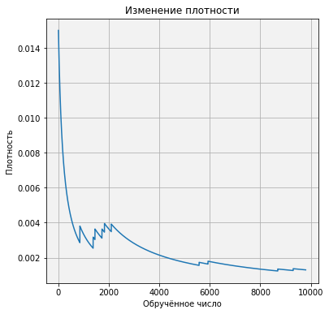

```python
densities=[(len(list(filter(lambda x: x < i, sorted(flat_list))))-1)/i for i in range(200,10000)]
drawPlot(densities,"Изменение плотности","Плотность","Обручённое число")
```

Ого. Плотность стремительно идёт к нулю

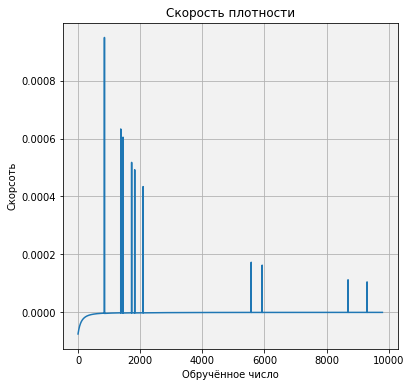

```python
ddensities = [densities[i]-densities[i-1] for i in range(1,len(densities))]
drawPlot(ddensities,title="Скорость плотности",x="Обручённое число",y="Скорсоть")
```

Кстати, а теперь если приглядется на линии, которые появились на графике скорости плотности, то мы поймём, что это точки перегиба!

### Статистика

Узнаем сколько чётных и нечётных чисел в последовательности?

```python
InteractiveShell.ast_node_interactivity = "last"

EvenBetrothed=[i for i in flat_list if(i%2==0)]
len(EvenBetrothed)
```

```
17
```

```
''
```

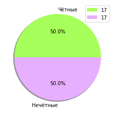

```python
plt.pie([len(EvenBetrothed),34-len(EvenBetrothed)],
        colors=["#A7FF5B","#E7AFFF"],
        labels=["Чётные","Нечётные"],
        autopct='%1.1f%%',
        shadow=True,
        textprops={'color':"black"})
plt.legend([len(EvenBetrothed),34-len(EvenBetrothed)])
;
```

Идеальный баланс!

Исследуем теперь на простоту!

```python
def _isPrime(n):
    if n%2==0:
        return n==2
    d=3
    while d*d<=n and n%d!=0:
        d+=2
    return d*d>n
```

```
''
```

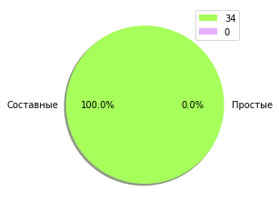

```python
PrimeBetrothed=[(i) for i in flat_list if(_isPrime(int(i)))]
plt.pie([34-len(PrimeBetrothed),len(PrimeBetrothed)],
        colors=["#A7FF5B","#E7AFFF"],
        labels=["Составные","Простые"],
        autopct='%1.1f%%',
        shadow=True,
        textprops={'color':"black"})
plt.legend([34-len(PrimeBetrothed),len(PrimeBetrothed)])
;
```

Ни одного простого числа! Вот так забава.

### Фракталы

Посмотрим, а можно ли нарисовать какие-то картинки по данному ряду?

```python
ratio=[flat_list[i]/flat_list[i-1] for i in range(1,len(flat_list))]
```

$ угол={{2 \pi }\over{x^2}} $

```python
np.mean(ratio)
```

```
1.5267131382431978
```

```python
angle=sp.N(360/np.mean(ratio)**2)
angle
```

$\displaystyle 154.449894093916$

```python
#Создаём картинку 300х300

N=300
t = turtle.Turtle(fixed=False, width=N, height=N)
t.hideturtle()
t
```

[output not shown]

```python
for i in range(15):
    for j in range(int(angle)):
        t.forward(i/10)
        t.left(1)
        if(i>10):
            time.sleep(0.01) # Чтобы не терять рисунок
```

```python
t = turtle.Turtle(fixed=False, width=N, height=N)
t.hideturtle()
t
```

[output not shown]

```python
for i in range(15):
    angle=sp.N(360/ratio[i]**2)
    for j in range(int(angle)):
        t.forward(i/10)
        t.left(1)
        if(i>10):
            time.sleep(0.04) # Чтобы не терять рисунок
```

### Подведём итог

Квази-дружественные (обрученные) числа имеют очень много похожих свойств с компанейскими и дружественными числами. И это удивляет.

# Конец

На этом всё, дорогие читатели!  
Надеюсь вам было интересно узнать что-то вроде такого из занимательной математики 😍

Прошлый раз я обещал расказать про совершенные числа, но у меня не хватает времени пока, что. Поэтому я успел сделать такую статью) Если у вас есть мысли или пожелания, обязательно напишите...Может найду что подправить или добавить.